# Data Analysis of EPL 2019/20 Season - The Lockdown Games

Ashraf Uddin Tafadar

2024-01-21

## Data set,Intentions and Approach

After Downloading the data from https://www.kaggle.com/datasets/idoyo92/epl-stats-20192020/data we will get two data set. One about the player statistics and another about team statistics. As our research question refers to the analysis of team data, my approach is to first have a basic exploration (descriptive statistics, basic exploratory data analysis) of player data set and an in-depth analysis of team data to find new trends. Merging the data set will result in redundancy. For example, in player data a players ‘influence’/‘creativity’/‘threat’ adds in his teams xG(expected goals).

```r
player <- read.csv("players_1920_fin.csv",TRUE,",")
head(player)
```

```
##   X assists bonus bps clean_sheets creativity element fixture goals_conceded
## 1 1       0     0   1            0        0.1     534      37              1
## 2 2       0     0   1            0        0.3     534      43              1
## 3 3       0     0   1            0        4.8     534      58              0
## 4 4       0     0   2            0        0.6     534      63              1
## 5 5       0     3  53            1       23.8     534      72              0
## 6 6       0     0   3            0       10.6     534      81              1
##   goals_scored ict_index influence     kickoff_time minutes    opponent_team
## 1            0       0.0       0.2 31/08/2019 14:00      24         Man City
## 2            0       2.2       1.0 14/09/2019 14:00       6          Burnley
## 3            0       2.5       2.0 21/09/2019 16:30      20 Newcastle United
## 4            0       0.1       0.2 28/09/2019 14:00      25          Chelsea
## 5            2      20.1      70.2 05/10/2019 11:30      79        Tottenham
## 6            0       3.6       4.4 19/10/2019 14:00      45      Aston Villa
##   own_goals penalties_missed penalties_saved red_cards round saves selected
```

[output cut: 20 more lines]

```r
#glimpse(player)
```

The data set has 22,502 observations in 35 variables.

‘X’: referring the row numbers.  
‘assists’: assists for scoring goals.  
‘bonus’: is fantasy game points.  
‘bps’: is bonus point system which is also fantasy aspect.  
‘clean_sheet’: clean sheet refers to zero goals scored by opponents.  
‘creativity’: Creativity is a statistic that measures a player’s ability to produce goal-scoring opportunities for their teammates.  
‘element’: in Fantasy Premier League (FPL), an “element” refers to a player. Each player available for selection in the Fantasy Premier League is categorized as an element.  
‘fixture’: doesn’t have any associated value.  
‘goals_conceded’:number of conceded goals.  
‘goals_scored’: number of scored goals.  
‘influence’: Influence measures a player’s impact on a match.  
‘creativity’: Creativity is a statistic that measures a player’s ability to produce goal-scoring opportunities for their teammates.  
‘threat’: Threat assesses a player’s goal-scoring potential. ‘ict_index’: culmination of ‘influence’,‘creativity’ and ‘threat’.High ICT Index scores indicate players who are actively involved in the game, contribute offensively, and pose a goal-scoring threat.  
‘kickoff_time’: the time game started.  
‘minutes’: minutes played by the player.  
‘own_goal’: own goal caused by that player.  
‘penalties_missed’: number of penalty missed.  
‘penalties_saved’: number of penalty saved.  
‘red_cards’: number of red cards taken by a player.  
‘round’: number of gameweeks.  
‘saves’: number of saves by goal-keeper.  
‘team_a_score’: teams away score.  
‘team_h_score’: teams home score.  
‘was_home’: home or away?  
‘yellow_cards’: number of yellow cards.  
‘full’: full name of the player.  
‘team’: players team. ‘total_points’: is the fantasy points they had.  
‘selected’: is how many the player was selected in total including that match.  
‘transfers_in’: how many people took them in their fantasy team around the time period of that match.  
‘transfers_out’: how many people dropped them from their fantasy team around the time period of that match.  
‘transfers_balance’: ‘transfers_in’-‘transfers_out’.  
‘value’: players fantasy value in millions.  
‘ppm’: fantasy points per match.

## Descriptive Statistics

```r
summary(player)
```

```
##        X            assists            bonus             bps
##  Min.   :    1   Min.   :0.00000   Min.   :0.0000   Min.   :-12.000
##  1st Qu.: 5626   1st Qu.:0.00000   1st Qu.:0.0000   1st Qu.:  0.000
##  Median :11252   Median :0.00000   Median :0.0000   Median :  0.000
##  Mean   :11252   Mean   :0.04004   Mean   :0.1079   Mean   :  6.115
##  3rd Qu.:16877   3rd Qu.:0.00000   3rd Qu.:0.0000   3rd Qu.: 10.000
##  Max.   :22502   Max.   :3.00000   Max.   :3.0000   Max.   : 90.000
##   clean_sheets      creativity         element         fixture
##  Min.   :0.0000   Min.   :  0.000   Min.   :  1.0   Min.   :  1.0
##  1st Qu.:0.0000   1st Qu.:  0.000   1st Qu.:149.0   1st Qu.:104.0
##  Median :0.0000   Median :  0.000   Median :297.0   Median :203.0
##  Mean   :0.1043   Mean   :  4.848   Mean   :299.1   Mean   :198.6
##  3rd Qu.:0.0000   3rd Qu.:  2.800   3rd Qu.:448.0   3rd Qu.:294.8
##  Max.   :1.0000   Max.   :133.500   Max.   :669.0   Max.   :380.0
##  goals_conceded    goals_scored       ict_index        influence
##  Min.   :0.0000   Min.   :0.00000   Min.   : 0.000   Min.   :  0.000
##  1st Qu.:0.0000   1st Qu.:0.00000   1st Qu.: 0.000   1st Qu.:  0.000
##  Median :0.0000   Median :0.00000   Median : 0.000   Median :  0.000
##  Mean   :0.5055   Mean   :0.04448   Mean   : 1.782   Mean   :  7.396
##  3rd Qu.:1.0000   3rd Qu.:0.00000   3rd Qu.: 2.600   3rd Qu.: 11.200
##  Max.   :9.0000   Max.   :4.00000   Max.   :35.800   Max.   :144.000
##  kickoff_time          minutes      opponent_team        own_goals
##  Length:22502       Min.   : 0.00   Length:22502       Min.   :0.000000
##  Class :character   1st Qu.: 0.00   Class :character   1st Qu.:0.000000
##  Mode  :character   Median : 0.00   Mode  :character   Median :0.000000
##                     Mean   :33.29                      Mean   :0.001466
##                     3rd Qu.:90.00                      3rd Qu.:0.000000
##                     Max.   :90.00                      Max.   :1.000000
##  penalties_missed    penalties_saved       red_cards         round
##  Min.   :0.0000000   Min.   :0.0000000   Min.   :0.000   Min.   : 1.00
##  1st Qu.:0.0000000   1st Qu.:0.0000000   1st Qu.:0.000   1st Qu.:11.00
##  Median :0.0000000   Median :0.0000000   Median :0.000   Median :21.00
##  Mean   :0.0008888   Mean   :0.0007555   Mean   :0.002   Mean   :20.34
##  3rd Qu.:0.0000000   3rd Qu.:0.0000000   3rd Qu.:0.000   3rd Qu.:30.00
##  Max.   :1.0000000   Max.   :2.0000000   Max.   :1.000   Max.   :38.00
##      saves             selected        team_a_score    team_h_score
##  Min.   : 0.00000   Min.   :      0   Min.   :0.000   Min.   :0.000
##  1st Qu.: 0.00000   1st Qu.:   7397   1st Qu.:0.000   1st Qu.:1.000
##  Median : 0.00000   Median :  28836   Median :1.000   Median :1.000
##  Mean   : 0.09879   Mean   : 181434   Mean   :1.199   Mean   :1.514
```

[output cut: 8 more lines]

```
##  Max.   :181.00   Max.   :26.000   Max.   :  984950.0   Max.   :1030761
##  transfers_out         value         was_home        yellow_cards
##  Min.   :      0   Min.   : 3.800   Mode :logical   Min.   :0.00000
##  1st Qu.:    180   1st Qu.: 4.400   FALSE:11259     1st Qu.:0.00000
##  Median :   1102   Median : 4.900   TRUE :11243     Median :0.00000
##  Mean   :  10810   Mean   : 5.171                   Mean   :0.05684
##  3rd Qu.:   6591   3rd Qu.: 5.500                   3rd Qu.:0.00000
##  Max.   :1263230   Max.   :12.800                   Max.   :1.00000
##      full               team                ppm
##  Length:22502       Length:22502       Min.   :-1.2500
##  Class :character   Class :character   1st Qu.: 0.0000
##  Mode  :character   Mode  :character   Median : 0.0000
##                                        Mean   : 0.2497
##                                        3rd Qu.: 0.3333
##                                        Max.   : 4.4681
```

## Data Preparation and Pre-Processing.

```r
sapply(player, function(x) sum(is.na(x)))
```

```
##                 X           assists             bonus               bps
##                 0                 0                 0                 0
##      clean_sheets        creativity           element           fixture
##                 0                 0                 0                 0
##    goals_conceded      goals_scored         ict_index         influence
##                 0                 0                 0                 0
##      kickoff_time           minutes     opponent_team         own_goals
##                 0                 0                 0                 0
##  penalties_missed   penalties_saved         red_cards             round
##                 0                 0                 0                 0
##             saves          selected      team_a_score      team_h_score
##                 0                 0                 0                 0
##            threat      total_points transfers_balance      transfers_in
##                 0                 0                 0                 0
##     transfers_out             value          was_home      yellow_cards
##                 0                 0                 0                 0
##              full              team               ppm
##                 0                 0                 0
```

There is no missing values in player data set.

### Dropping variables and the intentions behind them.

Most of the variable in player data set are from Fantasy Premier League (www.premierleague.com, n.d.) which may include statistics like how much they cost, how many people owns them, transfers, etc. In other word, irrelevant in our case.

Dropping the first ‘X’ column which is just row numbers and doesn’t have any significant value.  
As we have ‘ict_index’ of a player which was gained by ‘influence’,‘creativity’, and ‘threat.So the later three variables would be redundant.  
’bonus’: is fantasy game points.  
‘bps’: is bonus point system which is also fantasy aspect.  
‘fixture’: doesn’t have any associated value.  
‘element’: in Fantasy Premier League (FPL), an “element” refers to a player. Each player available for selection in the Fantasy Premier League is categorized as an element.  
‘total_points’: is the fantasy points they had.  
‘selected’: is how many the player was selected in total including that match.  
‘transfers_in’: how many people took them in their fantasy team around the time period of that match.  
‘transfers_out’: how many people dropped them from their fantasy team around the time period of that match.  
‘transfers_balance’: ‘transfers_in’-‘transfers_out’.  
‘value’: players fantasy value in millions.  
‘ppm’: fantasy points per match.

```r
#dropping variables using subset function
player = subset(player, select = -c(X,influence, creativity, threat, bonus, bps, fixture, element, total_points, selected, transfers_in, transfers_out, transfers_balance, value, ppm))
head(player)
```

```
##   assists clean_sheets goals_conceded goals_scored ict_index     kickoff_time
## 1       0            0              1            0       0.0 31/08/2019 14:00
## 2       0            0              1            0       2.2 14/09/2019 14:00
## 3       0            0              0            0       2.5 21/09/2019 16:30
## 4       0            0              1            0       0.1 28/09/2019 14:00
## 5       0            1              0            2      20.1 05/10/2019 11:30
## 6       0            0              1            0       3.6 19/10/2019 14:00
##   minutes    opponent_team own_goals penalties_missed penalties_saved red_cards
## 1      24         Man City         0                0               0         0
## 2       6          Burnley         0                0               0         0
## 3      20 Newcastle United         0                0               0         0
## 4      25          Chelsea         0                0               0         0
## 5      79        Tottenham         0                0               0         0
## 6      45      Aston Villa         0                0               0         0
##   round saves team_a_score team_h_score was_home yellow_cards           full
## 1     4     0            0            4    FALSE            0 Aaron Connolly
## 2     5     0            1            1     TRUE            0 Aaron Connolly
## 3     6     0            0            0    FALSE            0 Aaron Connolly
## 4     7     0            0            2    FALSE            0 Aaron Connolly
## 5     8     0            0            3     TRUE            0 Aaron Connolly
## 6     9     0            1            2    FALSE            0 Aaron Connolly
##       team
## 1 Brighton
## 2 Brighton
## 3 Brighton
## 4 Brighton
## 5 Brighton
## 6 Brighton
```

```r
summary(player)
```

```
##     assists         clean_sheets    goals_conceded    goals_scored
##  Min.   :0.00000   Min.   :0.0000   Min.   :0.0000   Min.   :0.00000
##  1st Qu.:0.00000   1st Qu.:0.0000   1st Qu.:0.0000   1st Qu.:0.00000
##  Median :0.00000   Median :0.0000   Median :0.0000   Median :0.00000
##  Mean   :0.04004   Mean   :0.1043   Mean   :0.5055   Mean   :0.04448
##  3rd Qu.:0.00000   3rd Qu.:0.0000   3rd Qu.:1.0000   3rd Qu.:0.00000
##  Max.   :3.00000   Max.   :1.0000   Max.   :9.0000   Max.   :4.00000
##    ict_index      kickoff_time          minutes      opponent_team
##  Min.   : 0.000   Length:22502       Min.   : 0.00   Length:22502
##  1st Qu.: 0.000   Class :character   1st Qu.: 0.00   Class :character
##  Median : 0.000   Mode  :character   Median : 0.00   Mode  :character
##  Mean   : 1.782                      Mean   :33.29
##  3rd Qu.: 2.600                      3rd Qu.:90.00
##  Max.   :35.800                      Max.   :90.00
##    own_goals        penalties_missed    penalties_saved       red_cards
##  Min.   :0.000000   Min.   :0.0000000   Min.   :0.0000000   Min.   :0.000
##  1st Qu.:0.000000   1st Qu.:0.0000000   1st Qu.:0.0000000   1st Qu.:0.000
##  Median :0.000000   Median :0.0000000   Median :0.0000000   Median :0.000
##  Mean   :0.001466   Mean   :0.0008888   Mean   :0.0007555   Mean   :0.002
##  3rd Qu.:0.000000   3rd Qu.:0.0000000   3rd Qu.:0.0000000   3rd Qu.:0.000
##  Max.   :1.000000   Max.   :1.0000000   Max.   :2.0000000   Max.   :1.000
##      round           saves           team_a_score    team_h_score
##  Min.   : 1.00   Min.   : 0.00000   Min.   :0.000   Min.   :0.000
##  1st Qu.:11.00   1st Qu.: 0.00000   1st Qu.:0.000   1st Qu.:1.000
##  Median :21.00   Median : 0.00000   Median :1.000   Median :1.000
##  Mean   :20.34   Mean   : 0.09879   Mean   :1.199   Mean   :1.514
##  3rd Qu.:30.00   3rd Qu.: 0.00000   3rd Qu.:2.000   3rd Qu.:2.000
##  Max.   :38.00   Max.   :12.00000   Max.   :9.000   Max.   :8.000
##   was_home        yellow_cards         full               team
##  Mode :logical   Min.   :0.00000   Length:22502       Length:22502
##  FALSE:11259     1st Qu.:0.00000   Class :character   Class :character
##  TRUE :11243     Median :0.00000   Mode  :character   Mode  :character
##                  Mean   :0.05684
##                  3rd Qu.:0.00000
##                  Max.   :1.00000
```

Some variable name sounds ambiguous. Lets give them appropriate name.

```r
# using rename function of dplyr package
player <- player %>%
  rename(Player = full, GameWeek = round)
glimpse(player)
```

```
## Rows: 22,502
## Columns: 20
## $ assists          <int> 0, 0, 0, 0, 0, 0, 2, 0, 0, 0, 0, 0, 0, 0, 0, 0, 0, 0,…
## $ clean_sheets     <int> 0, 0, 0, 0, 1, 0, 0, 1, 0, 0, 0, 0, 0, 0, 0, 0, 0, 0,…
## $ goals_conceded   <int> 1, 1, 0, 1, 0, 1, 2, 0, 2, 0, 2, 1, 0, 0, 0, 1, 0, 0,…
## $ goals_scored     <int> 0, 0, 0, 0, 2, 0, 0, 0, 0, 0, 0, 0, 0, 0, 0, 0, 0, 0,…
## $ ict_index        <dbl> 0.0, 2.2, 2.5, 0.1, 20.1, 3.6, 0.2, 4.8, 0.3, 0.0, 2.…
## $ kickoff_time     <chr> "31/08/2019 14:00", "14/09/2019 14:00", "21/09/2019 1…
## $ minutes          <int> 24, 6, 20, 25, 79, 45, 79, 85, 45, 0, 75, 75, 0, 0, 4…
## $ opponent_team    <chr> "Man City", "Burnley", "Newcastle United", "Chelsea",…
## $ own_goals        <int> 0, 0, 0, 0, 0, 0, 0, 0, 0, 0, 0, 0, 0, 0, 0, 0, 0, 0,…
## $ penalties_missed <int> 0, 0, 0, 0, 0, 0, 0, 0, 0, 0, 0, 0, 0, 0, 0, 0, 0, 0,…
## $ penalties_saved  <int> 0, 0, 0, 0, 0, 0, 0, 0, 0, 0, 0, 0, 0, 0, 0, 0, 0, 0,…
## $ red_cards        <int> 0, 0, 0, 0, 0, 0, 0, 0, 0, 0, 0, 0, 0, 0, 0, 0, 0, 0,…
## $ GameWeek         <int> 4, 5, 6, 7, 8, 9, 10, 11, 12, 13, 14, 15, 16, 17, 18,…
## $ saves            <int> 0, 0, 0, 0, 0, 0, 0, 0, 0, 0, 0, 0, 0, 0, 0, 0, 0, 0,…
## $ team_a_score     <int> 0, 1, 0, 0, 0, 1, 2, 0, 1, 2, 1, 2, 2, 1, 1, 1, 0, 1,…
## $ team_h_score     <int> 4, 1, 0, 2, 3, 2, 3, 2, 3, 0, 2, 1, 2, 1, 0, 2, 2, 1,…
## $ was_home         <lgl> FALSE, TRUE, FALSE, FALSE, TRUE, FALSE, TRUE, TRUE, F…
## $ yellow_cards     <int> 0, 0, 0, 0, 0, 0, 0, 0, 0, 0, 0, 0, 0, 0, 0, 0, 0, 0,…
## $ Player           <chr> "Aaron Connolly", "Aaron Connolly", "Aaron Connolly",…
## $ team             <chr> "Brighton", "Brighton", "Brighton", "Brighton", "Brig…
```

```r
# taking some variables and making a data frame for a overall view of a players performance.
player_summary <- player %>%
  group_by(Player) %>%
  summarise(
    Team = unique(team),
    Home_Matches = sum(was_home == TRUE),
    Away_Matches = sum(was_home == FALSE),
    Matches_Played = Home_Matches + Away_Matches,
    Assists = sum(assists),
    Clean_Sheets = sum(clean_sheets),
    Goals_Conceded = sum(goals_conceded),
    Goals_Scored = sum(goals_scored),
    ICT_index = sum(ict_index),
    Minutes_Played = sum(minutes),
    Own_Goals = sum(own_goals),
    Penalties_Missed = sum(penalties_missed),
    Penalties_Saved = sum(penalties_saved),
    Red_Cards = sum(red_cards),
    Yellow_Cards = sum(yellow_cards),
    Saves =  sum(saves)
  )
print(player_summary)
```

```
## # A tibble: 673 × 17
## # Groups:   Player [666]
##    Player    Team  Home_Matches Away_Matches Matches_Played Assists Clean_Sheets
##    <chr>     <chr>        <int>        <int>          <int>   <int>        <int>
##  1 ?aglar S… Leic…           19           19             38       1           12
##  2 ?rjan Ny… Asto…           19           19             38       0            1
##  3 Aaron Co… Brig…           17           18             35       3            5
##  4 Aaron Cr… West…           19           19             38       0            5
##  5 Aaron Le… Burn…           19           19             38       0            0
##  6 Aaron Mo… Brig…           19           19             38       2            6
##  7 Aaron Ra… Bour…           19           19             38       1            5
##  8 Aaron Wa… Man …           19           19             38       4           12
##  9 Abd-Al-A… Burn…            8            9             17       0            0
## 10 Abdoulay… Watf…           19           19             38       4           10
## # ℹ 663 more rows
## # ℹ 10 more variables: Goals_Conceded <int>, Goals_Scored <int>,
## #   ICT_index <dbl>, Minutes_Played <int>, Own_Goals <int>,
## #   Penalties_Missed <int>, Penalties_Saved <int>, Red_Cards <int>,
## #   Yellow_Cards <int>, Saves <int>
```

```r
# player home stats
home_summary <- player %>%
  filter(was_home == TRUE) %>%
  summarise(
    ict_index = sum(ict_index),
    minutes_played = sum(minutes),
    assists = sum(assists),
    goals_scored = sum(goals_scored),
    penalties_missed = sum(penalties_missed),
    red_cards = sum(red_cards),
    yellow_cards = sum(yellow_cards)
  )
print(home_summary)
```

```
##   ict_index minutes_played assists goals_scored penalties_missed red_cards
## 1   21083.2         374562     499          554                2        22
##   yellow_cards
## 1          605
```

```r
away_summary <- player %>%
  filter(was_home == FALSE) %>%
  summarise(
    ict_index = sum(ict_index),
    minutes_played = sum(minutes),
    assists = sum(assists),
    goals_scored = sum(goals_scored),
    penalties_missed = sum(penalties_missed),
    red_cards = sum(red_cards),
    yellow_cards = sum(yellow_cards)
  )
print(away_summary)
```

```
##   ict_index minutes_played assists goals_scored penalties_missed red_cards
## 1   19023.5         374577     402          447               18        23
##   yellow_cards
## 1          674
```

These extracted data frame could be used for exploratory data analysis.One research question I want to add with player data set is that: ### Goalkeeprs, Defenders, Midfielders or Strikers, which category of player had better performance?

The research question assigned to me was:

## Is there a relationship between playing behind closed doors and team performance in football matches during the 2019/2020 season? Performance is classified on the basis of wins, losses, and draws.

I think closed doors refers to no live audience, or home audience, because home fans support, motivation, etc plays and unmeasurable part in the game of football. I will try to analyse team aspects in light of Home and Away matches.If there is significant trends in any side, we could come to some valuable conclusion or insight.

## Introduction of Data-set

```r
team <- read.csv("epl2020.csv",TRUE,",")
head(team)
```

```
##   X h_a       xG      xGA     npxG    npxGA deep deep_allowed scored missed
## 1 1   h 2.234560 0.842407 2.234560 0.842407   11            5      4      1
## 2 2   a 0.842407 2.234560 0.842407 2.234560    5           11      1      4
## 3 3   a 3.183770 1.200300 2.422640 1.200300    9            1      5      0
## 4 4   h 1.200300 3.183770 1.200300 2.422640    1            9      0      5
## 5 5   h 1.340990 1.598640 1.340990 1.598640    4            6      1      1
## 6 6   a 0.855516 0.670022 0.855516 0.670022    5            7      3      0
##     xpts result                date wins draws loses pts     npxGD      teamId
## 1 2.3863      w 2019-08-09 20:00:00    1     0     0   3  1.392153   Liverpool
## 2 0.4405      l 2019-08-09 20:00:00    0     0     1   0 -1.392153     Norwich
## 3 2.6312      w 2019-08-10 12:30:00    1     0     0   3  1.222340    Man City
## 4 0.2522      l 2019-08-10 12:30:00    0     0     1   0 -1.222340    West Ham
## 5 1.0172      d 2019-08-10 15:00:00    0     1     0   1 -0.257650 Bournemouth
## 6 1.5458      w 2019-08-10 15:00:00    1     0     0   3  0.185494    Brighton
##    ppda_cal allowed_ppda matchtime tot_points round tot_goal tot_con Referee.x
```

[output cut: 20 more lines]

Each row represents data about the game. There are 576 observations, so there are 288 games in total. Because one row is for home team data another for away team.For example, First two rows represents Liverpool and Norwich match data.

The data set includes (45 columns) lots of different statistics about the football game: str(team) gives us the datatype of each variable.

X = Indicator for row numbers.  
h_a = Teams playing home or away.  
xG = Expected goals.  
xGA = Expected goals against.  
npxG = Non-penalty Expected goals.  
npxGA = Non-penalty expected goals against.  
deep,deep allowed = ‘deep’ is number of final third entries in opponent side and ‘deep allowed’ is allowed final third entries of opponents.  
xpts = Expected points of a team.  
npxGD = non-penalty expected goal difference  
ppda_cal, allowed ppda = Passes Per Defensive Action.What number of passes was played before a defensive action was taken.  
HS = Home Team Shots.  
HST = Home Team Shots on Target.  
HF = Home Team Fouls Committed.  
HC = Home Team Corners.  
HY = Home Team Yellow Cards.  
HR = Home Team Red Cards.  
AS = Away Team Shots.  
AST = Away Team Shots on Target.  
AC = Away Team Corners.  
AF = Away Team Fouls Committed.  
AY = Away Team Yellow Cards.  
AR = Away Team Red Cards.  
HtrgPerc = Shooting Accuracy Percentage.  
AtrgPerc = Attack Accuracy Percentage.  
scored = Goals scored in that match.  
missed = Goals conceded in that match.  
results = Match result(target class).  
date = Match date.  
matchTime = match time.  
B365H.x = Betting odds in Home.  
B365D.x = Betting odds for a Draw.  
B365A.x = Betting odds in Away.  
pts = Points in that match.  
tot_points = match points + previous points.  
tot_goal = match goals + previous goals.  
round = Match weeks.  
wins, draws, loses = Match results.  
tot_con = match conceded goals + previous conceded goals.  
matchDay = Day of the week.  
Referee.x = Match officials.  
teamId = team name.

```r
summary(team)
```

```
##        X             h_a                  xG               xGA
##  Min.   :  1.0   Length:576         Min.   :0.05413   Min.   :0.05413
##  1st Qu.:144.8   Class :character   1st Qu.:0.84003   1st Qu.:0.84003
##  Median :288.5   Mode  :character   Median :1.27536   Median :1.27536
##  Mean   :288.5                      Mean   :1.46009   Mean   :1.46009
##  3rd Qu.:432.2                      3rd Qu.:1.97355   3rd Qu.:1.97355
##  Max.   :576.0                      Max.   :6.63049   Max.   :6.63049
##       npxG             npxGA              deep         deep_allowed
##  Min.   :0.05413   Min.   :0.05413   Min.   : 0.000   Min.   : 0.000
##  1st Qu.:0.78406   1st Qu.:0.78406   1st Qu.: 4.000   1st Qu.: 4.000
##  Median :1.23067   Median :1.23067   Median : 6.000   Median : 6.000
##  Mean   :1.37181   Mean   :1.37181   Mean   : 6.623   Mean   : 6.623
##  3rd Qu.:1.86949   3rd Qu.:1.86949   3rd Qu.: 9.000   3rd Qu.: 9.000
##  Max.   :5.86932   Max.   :5.86932   Max.   :31.000   Max.   :31.000
##      scored          missed           xpts           result
##  Min.   :0.000   Min.   :0.000   Min.   :0.0004   Length:576
##  1st Qu.:0.000   1st Qu.:0.000   1st Qu.:0.6368   Class :character
##  Median :1.000   Median :1.000   Median :1.3214   Mode  :character
##  Mean   :1.361   Mean   :1.361   Mean   :1.3920
##  3rd Qu.:2.000   3rd Qu.:2.000   3rd Qu.:2.1387
##  Max.   :9.000   Max.   :9.000   Max.   :2.9992
##      date                wins           draws          loses
##  Length:576         Min.   :0.000   Min.   :0.00   Min.   :0.000
##  Class :character   1st Qu.:0.000   1st Qu.:0.00   1st Qu.:0.000
##  Mode  :character   Median :0.000   Median :0.00   Median :0.000
##                     Mean   :0.375   Mean   :0.25   Mean   :0.375
##                     3rd Qu.:1.000   3rd Qu.:0.25   3rd Qu.:1.000
##                     Max.   :1.000   Max.   :1.00   Max.   :1.000
##       pts            npxGD            teamId             ppda_cal
##  Min.   :0.000   Min.   :-5.5246   Length:576         Min.   : 3.189
##  1st Qu.:0.000   1st Qu.:-0.8727   Class :character   1st Qu.: 7.715
##  Median :1.000   Median : 0.0000   Mode  :character   Median :10.184
##  Mean   :1.375   Mean   : 0.0000                      Mean   :12.302
##  3rd Qu.:3.000   3rd Qu.: 0.8727                      3rd Qu.:14.439
##  Max.   :3.000   Max.   : 5.5246                      Max.   :60.000
##   allowed_ppda      matchtime       tot_points        round
##  Min.   : 3.189   Min.   :11.00   Min.   : 0.00   Min.   : 1.0
##  1st Qu.: 7.715   1st Qu.:14.00   1st Qu.: 9.00   1st Qu.: 8.0
##  Median :10.184   Median :15.00   Median :18.00   Median :15.0
##  Mean   :12.302   Mean   :15.52   Mean   :20.44   Mean   :14.9
```

[output cut: 29 more lines]

```
##  Max.   :16.000   Max.   :6.000   Max.   :1.0000   Max.   :15.000
##     B365D.x         B365A.x          HtrgPerc         AtrgPerc
##  Min.   : 3.10   Min.   : 1.140   Min.   :0.0000   Min.   :0.0000
##  1st Qu.: 3.40   1st Qu.: 2.300   1st Qu.:0.2475   1st Qu.:0.2500
##  Median : 3.75   Median : 3.350   Median :0.3333   Median :0.3333
##  Mean   : 4.32   Mean   : 4.774   Mean   :0.3484   Mean   :0.3613
##  3rd Qu.: 4.75   3rd Qu.: 5.750   3rd Qu.:0.4444   3rd Qu.:0.4545
##  Max.   :13.00   Max.   :26.000   Max.   :1.0000   Max.   :1.0000
##    matchDay
##  Length:576
##  Class :character
##  Mode  :character
##
##
##
```

Summary() provides us the minimum value,value of the 1st quartile (25th percentile), median,3rd quartile (75th percentile), and maximum value of numerical variables. For instance, if we look at the ‘xG’ variable There are little difference from min value(0.05) to 3rd quartile(1.97), but significant gap between 3rd and max value(6.63).We could assume 75% of the matches had less or equal to 2 expected of goals per game and 25% matches had more than 2 expected goals.We could have ideas about the distributions of variables from the summary.

## Data Preparation and Pre-Processing

```r
sapply(team, function(x) sum(is.na(x)))
```

```
##            X          h_a           xG          xGA         npxG        npxGA
##            0            0            0            0            0            0
##         deep deep_allowed       scored       missed         xpts       result
##            0            0            0            0            0            0
##         date         wins        draws        loses          pts        npxGD
##            0            0            0            0            0            0
##       teamId     ppda_cal allowed_ppda    matchtime   tot_points        round
##            0            0            0            0            0            0
##     tot_goal      tot_con    Referee.x         HS.x        HST.x         HF.x
##            0            0            0            0            0            0
##         HC.x         HY.x         HR.x         AS.x        AST.x         AF.x
##            0            0            0            0            0            0
##         AC.x         AY.x         AR.x      B365H.x      B365D.x      B365A.x
##            0            0            0            0            0            0
##     HtrgPerc     AtrgPerc     matchDay
##            0            0            0
```

There is no null or missing values in the data set.

## Cleaning the Data Set

```r
#using select() function to drop variables.
team = subset(team, select = -c(X,B365H.x, B365D.x,B365A.x,tot_goal, tot_con,round, wins, draws, loses))
colnames(team)
```

```
##  [1] "h_a"          "xG"           "xGA"          "npxG"         "npxGA"
##  [6] "deep"         "deep_allowed" "scored"       "missed"       "xpts"
## [11] "result"       "date"         "pts"          "npxGD"        "teamId"
## [16] "ppda_cal"     "allowed_ppda" "matchtime"    "tot_points"   "Referee.x"
## [21] "HS.x"         "HST.x"        "HF.x"         "HC.x"         "HY.x"
## [26] "HR.x"         "AS.x"         "AST.x"        "AF.x"         "AC.x"
## [31] "AY.x"         "AR.x"         "HtrgPerc"     "AtrgPerc"     "matchDay"
```

‘date’ consists of date+time.We could just transform the variable to date.We have separate variable for match time.

```r
team$date <- as.Date(team$date)
print(team$date,5)
```

```
## [1] "2019-08-09" "2019-08-09" "2019-08-10" "2019-08-10" "2019-08-10"
##  [ reached 'max' / getOption("max.print") -- omitted 571 entries ]
```

Let’s rename some variables into relevant name.

```r
# using rename function of dplyr package
team <- team %>%
  rename(conceded = missed, Home_Away = h_a)
colnames(team)
```

```
##  [1] "Home_Away"    "xG"           "xGA"          "npxG"         "npxGA"
##  [6] "deep"         "deep_allowed" "scored"       "conceded"     "xpts"
## [11] "result"       "date"         "pts"          "npxGD"        "teamId"
## [16] "ppda_cal"     "allowed_ppda" "matchtime"    "tot_points"   "Referee.x"
## [21] "HS.x"         "HST.x"        "HF.x"         "HC.x"         "HY.x"
## [26] "HR.x"         "AS.x"         "AST.x"        "AF.x"         "AC.x"
## [31] "AY.x"         "AR.x"         "HtrgPerc"     "AtrgPerc"     "matchDay"
```

We could re-organize the table columns to make it more suitable for our analysis.

```r
team <- team[, c("teamId","Home_Away","xpts","pts","tot_points","xG","npxG","scored","xGA","npxGA","conceded","npxGD","deep","deep_allowed","ppda_cal","allowed_ppda","HS.x","HST.x","HF.x","HC.x","HY.x","HR.x","AS.x","AST.x","AF.x","AC.x","AY.x","AR.x","HtrgPerc","AtrgPerc","date","matchtime","Referee.x","matchDay","result")]
colnames(team)
```

```
##  [1] "teamId"       "Home_Away"    "xpts"         "pts"          "tot_points"
##  [6] "xG"           "npxG"         "scored"       "xGA"          "npxGA"
## [11] "conceded"     "npxGD"        "deep"         "deep_allowed" "ppda_cal"
## [16] "allowed_ppda" "HS.x"         "HST.x"        "HF.x"         "HC.x"
## [21] "HY.x"         "HR.x"         "AS.x"         "AST.x"        "AF.x"
## [26] "AC.x"         "AY.x"         "AR.x"         "HtrgPerc"     "AtrgPerc"
## [31] "date"         "matchtime"    "Referee.x"    "matchDay"     "result"
```

## Exploratory Data Analysis

### Which days are among top playing days?

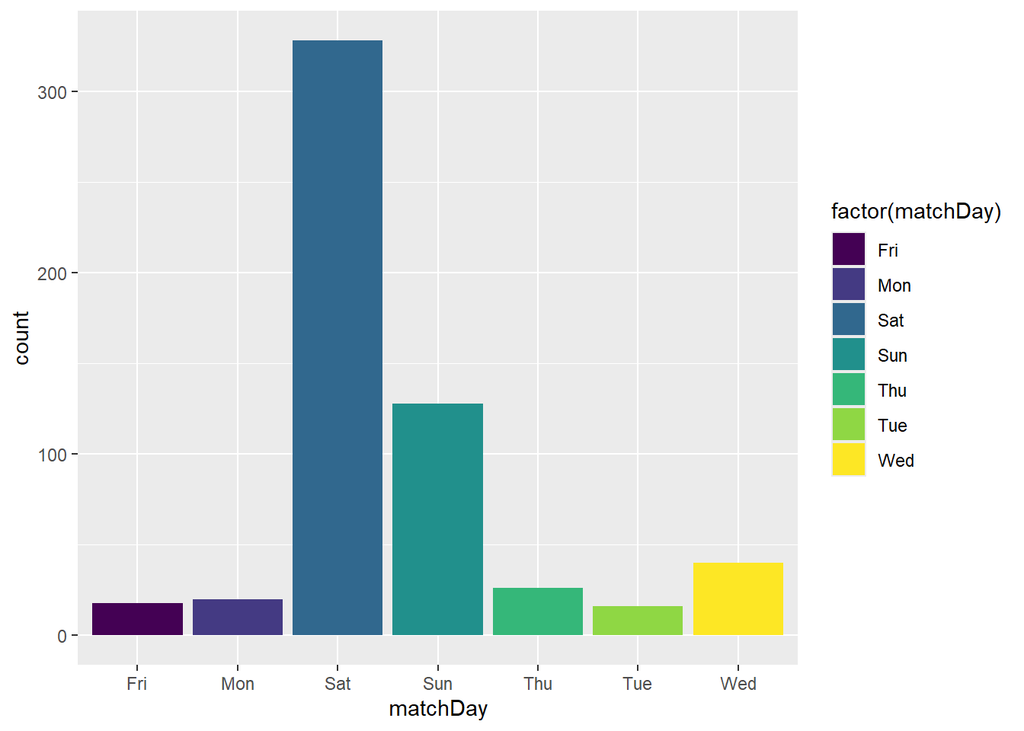

```r
ggplot(team) +
  geom_bar(mapping = aes(x = matchDay, fill = factor(matchDay))) +
  scale_fill_viridis_d()
```

The majority of matches were scheduled for Saturdays, indicating a substantial contrast between this day and the rest of the week.

### Are there any favoritism in match officials?

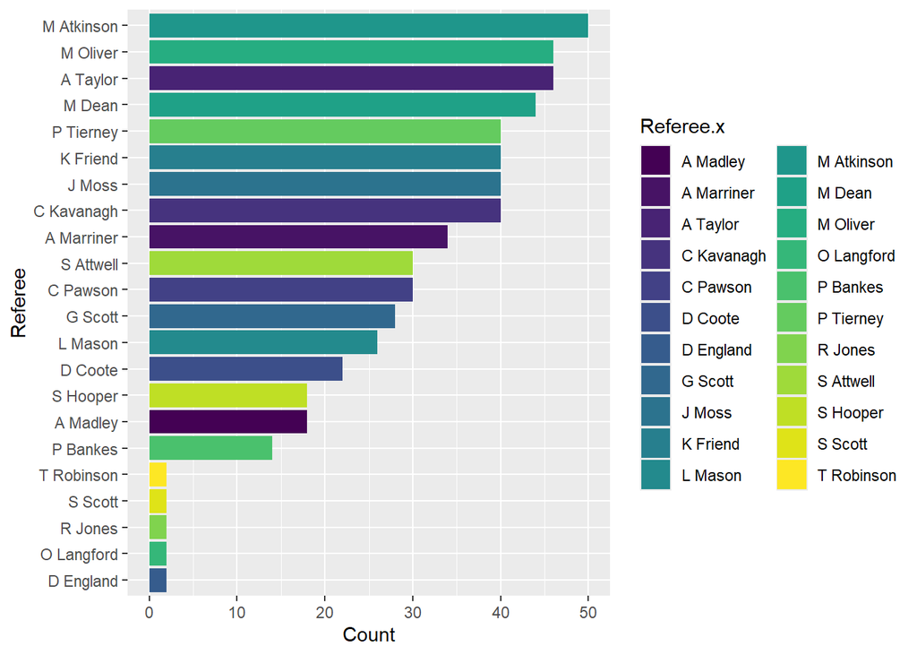

```r
ggplot(team) +
  geom_bar(mapping = aes(y = reorder(Referee.x, table(Referee.x)[Referee.x]), fill = Referee.x)) +
  scale_fill_viridis_d() +
  labs(x = "Count", y = "Referee")
```

There is no evident favoritism in match officiating observed across the 22 referees. Specifically, eight officials officiated over 40 or more matches.